# exchange_analytic

```python
from IPython.display import HTML

HTML('''<script>
code_show=true;
function code_toggle() {
 if (code_show){
 $('div.input').hide();
 } else {
 $('div.input').show();
 }
 code_show = !code_show
}
$( document ).ready(code_toggle);
</script>
<form action="javascript:code_toggle()"><input type="submit" value="Click here to toggle on/off the raw code."></form>''')
```

**Analytical expression for exchange rate of binaries as a function of the hardness parameter**

*Set-up:*

Consider a binary with two stars of mass $m_*$ and semi-major axis $a$. It encounters a compact object of mass $m_c$. The total mass of the three-body system is $M$ (we will assume $m_*\ll m_c$). The initial relative velocity of the star and binary is $v_\infty$. We assume it has a Maxwellian distribution with a dispersion, $\sigma$. The density of stars and remnants is $n_c$ and $n_*$.

*Cross-section for resonant exchange*

The cross-section for a resonant capture of the BH is

$\Sigma_{\rm res}=1.18 (n-1) (1-v^2)^{n-2} \frac{2 m_c}{m_*} \frac{\pi a^2}{v^2}$.

$v$ is a dimensionless velocity that $v^2= \frac{2 m_c}{M} \frac{v_\infty^2 a}{G m_*}$ (Valtonen and Kartunnen 2006). $v=1$ corresponds to a zero-energy encounter. $n$ depends on the total angular momentun of the encounter, and typically varies between 3 and 4.5 (*double check*). The cross-section goes to 0 as v approaches 1 (and is not well defined for v>1).

The rate of resonant exchanges per unit volume is

$\Gamma = n_c n_* <\Sigma_{\rm res} v_\infty>$,

where $<\Sigma_{\rm res} v_\infty> \equiv \int_{0}^{1} \Sigma_{\rm res} v_\infty f(v_\infty) d v_\infty\approx\\\frac{2 m_c}{m_*} \pi a^2 ( x^2-4+4 e^{-x^2/4}) \sigma=\\ \frac{2 G m_c}{\sigma} \pi a\frac{x^2-4 +4 e^{-x^2/4}}{x^2}$,

where $x^2\equiv\frac{G m_\star}{a \sigma^2}$ quantifies the *hardness* of the binary. We have assumed that n=3 in the above expression. Note that for x>>1, the above expression goes to $\frac{2 G m_c}{\sigma} \pi a$.

The plot below shows $<\Sigma_{\rm res} v_\infty>$ for n=3, 4, 5...

```python
import sympy
import numpy as np
import matplotlib.pyplot as plt
sympy.init_printing()

x, v=sympy.symbols('x v', positive=True)
c1=0.25*1.18*(2./np.pi)**0.5
def rate_integ(n):
    return sympy.integrate((n-1)*v*(1-v**2)**(n-2)*sympy.exp(-v**2*x**2/4)*x**4, (v,0,1))
```

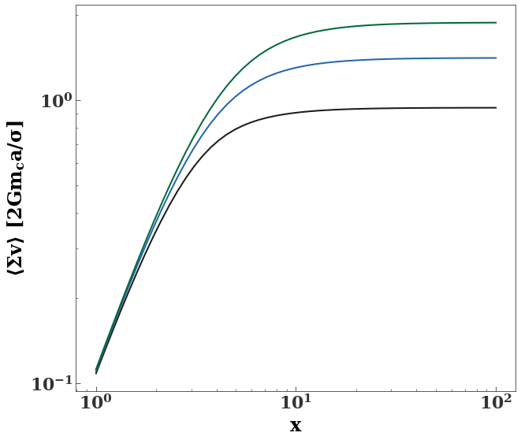

```python
fig,ax=plt.subplots(figsize=(10,9))
ax.set_ylabel(r'$\left<\Sigma v\right>\,\, [2 G m_c a/\sigma]$')
ax.set_xlabel('x')

xs=np.logspace(0, 2)
ns=range(3, 6)

rate_a=[rate_integ(i).simplify() for i in ns]
rate=[sympy.lambdify(x, rate_a[i], "numpy") for i in range(len(ns))]
rates=[c1*rate[i](xs)/xs**2. for i in range(len(ns))]

l1,=plt.loglog(xs, rates[0], label='n=3')
l2,=plt.loglog(xs, rates[1], label='n=4')
l3,=plt.loglog(xs, rates[2], label='n=5')
```